# riojaPlot: User Guide (Version 0.1-1)

### 16. How do I include special symbols in the variable names

We can pass a character vector of custom names for each column using style `x.names` and use `expression` to create names with superscripts, subscripts or greek letters.

```r
nms <- colnames(maule.data)
nms[8] <- expression(delta^15*N)
```

We can also use function `label_geochem` in package `tidypaleo` to automatically add annotations for a slected range of common geochemical variables.

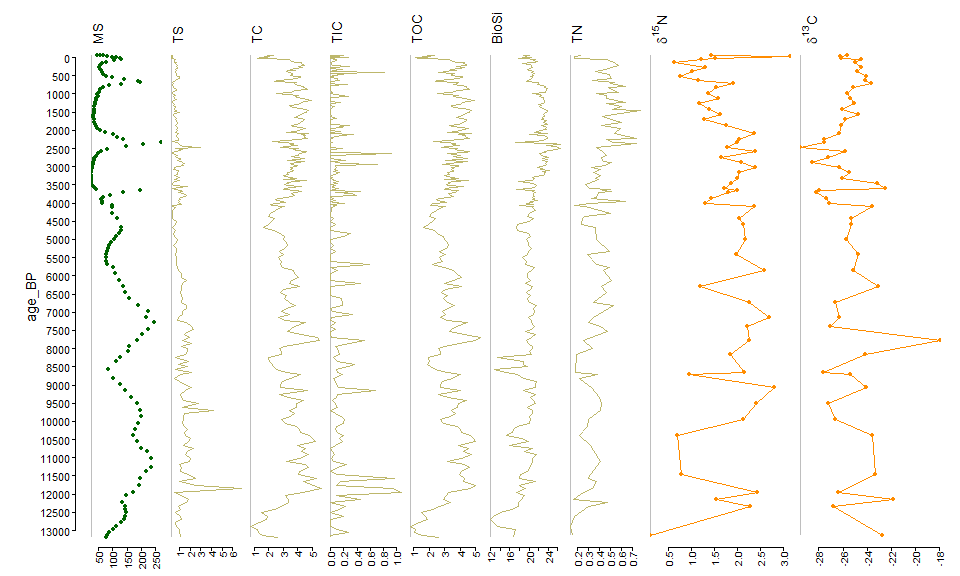

```r
library(tidypaleo)
nms <- colnames(maule.data)
nms2 <- as.expression(sapply(nms, function(x) unlist(label_geochem(x)[[1]])))
riojaPlot(maule.data, maule.chron, groups=groups,
          yvar.name="age_BP",
          x.names=nms2,
          ymin=-100,
          ymax=13300,
          yinterval=500,
          plot.bar=FALSE,
          plot.poly=FALSE,
          plot.line=selline,
          plot.symb=selsymb,
          plot.groups=TRUE,
          ylabPos=2.2,
          symb.cex=0.5,
          ytks1=myticks,
          las.axis=2,
          graph.widths=widths,
          yBottom=0.06
          )
```

## 11. List of modifiable styles and default values

| Style | Value |
| --- | --- |
| yvar.name |  |
| sec.yvar.name |  |
| ylabel |  |
| sec.ylabel |  |
| plot.sec.axis | FALSE |
| scale.percent | FALSE |
| scale.minmax | FALSE |
| y.rev | TRUE |
| ymin |  |
| ymax |  |
| yinterval |  |
| sec.ymin |  |
| sec.ymax |  |
| sec.yinterval |  |
| wa.order | none |
| plot.bar | TRUE |
| plot.line | TRUE |
| plot.poly | FALSE |
| plot.symb | FALSE |
| do.clust | FALSE |
| plot.clust | FALSE |
| plot.zones | 0 |
| lwd.bar | 1 |
| lwd.line | 1 |
| lwd.poly.line | 0.6 |
| lwd.cumul.line | 0.6 |
| col.bar | grey |
| bar.back | FALSE |
| col.symb | black |
| col.line | black |

[output cut: 68 more lines]

## 12. References

Allen, J.R.M. *et al*. (1999) Rapid environmental changes in southern Europe during the last glacial period. Nature, 400, 740-743.

Bennion, H. (1994) A diatom-phosphorus transfer function for shallow, eutrophic ponds in southeast England. *Hydrobiologia*, **275/276**, 391-410.

Frugone-Álvarez, M. et al. (2020) Volcanism and climate change as drivers in Holocene depositional dynamic of Laguna del Maule (Andes of central Chile - 36S). Climate of the Past, DOI 10.5194/cp-2019-147.